# CS559 Homework#3: Decision Tree and Ensemble Methods

## Due: 11/8/2021 Monday at 11:59 PM

In this assignment, you are going to implement four classifiers - **decision tree, random forest, adaboost, and gradient boost**. Then check the performance with `sklearn` built-in algorithms. In this work, splitting into train and test sets is not necessary.

```python
import numpy as np
import pandas as pd
import matplotlib.pyplot as plt
import seaborn as sns
from sklearn.preprocessing import StandardScaler, MinMaxScaler
from sklearn.tree import DecisionTreeClassifier
from sklearn.ensemble import RandomForestClassifier
from sklearn.ensemble import AdaBoostClassifier
from sklearn.ensemble import GradientBoostingClassifier
from sklearn.metrics import accuracy_score,classification_report
from sklearn.metrics import confusion_matrix
import warnings
warnings.filterwarnings("ignore")
```

```python
df = pd.read_csv('./F21_CS559_HW3_data.csv')
```

```python
df.head(5)
```

|  | a | b | c | class |
| --- | --- | --- | --- | --- |
| 0 | 9.4202 | -4.3507 | 10.3764 | 1 |
| 1 | 9.7044 | -4.4601 | 10.6803 | 1 |
| 2 | 9.8075 | -4.0894 | 10.6259 | 1 |
| 3 | 9.2771 | -4.0349 | 10.1166 | 1 |
| 4 | 9.6447 | -3.5968 | 10.2936 | 1 |

### Question 1: Decisition Tree Classifier

- A simple DT implementation (10 pts.)
  - to make the problem simple, implement a decision tree with depth of 3 (the root index is 0).
  - calculate the gini index for each attribute and pick the best attribute for each node.
  - calculate the accuracy using accuracy score.
- Classification using DecistionTreeClassifier (5 pts)
- Evaluation (5 pts)

```python
print(range(len(list(df['class']))))
```

```
range(0, 2500)
```

```python
# sorry, I may not able to show the algorithm, but this result might show some ideas.

def MyDecisitionTree(data,depth):

    m=data['class'].size
    # Count of each class in the current node.
    num_parent =[np.sum(y == c) for c in range(len(set(list(data['class']))))]
    #count gini impurity
    best_gini = 1.0-sum((n/m) **2 for n in num_parent)

    best_idx, best_thr = None, None

    for i in range depth:

        # loop all the feature
        for idx in range(data.iloc[:,:3]):

            thresholds, classes = zip(*sorted(zip(data.iloc[:,idx], data['class'])))

            num_left = [0] * data['class']
            num_right = num_parent.copy()

            for i in range(1,m):
                c = classes[i-1]
                num_left[c] += 1
                num_right[c] -= 1

                # count the gini index of left tree
                gini_left = 1.0 - sum((num_left[x] / i) ** 2 for x in range(len(set(list(data['class'])))))

                # count the gini index of right tree
                gini_right = 1.0 - sum((num_right[x] / (m - i)) ** 2 for x in range(len(set(list(data['class'])))))

                # gini impurity of a split is the weighted average of Gini
                gini = (i * gini_left + (m - i) * gini_right) / m

                if thresholds[i] == thresholds[i - 1]:
                        continue

                if gini < best_gini:
                    best_gini = gini
                    best_idx = idx
                    best_thr = (thresholds[i] + thresholds[i - 1]) / 2  # midpoint

        return best_idx, best_thr


# if the function works, we can use accuracy_score()
```

```python
X=df.iloc[:,:3]
y = df['class']
model = DecisionTreeClassifier(criterion='gini',max_depth=3)

clf = model.fit(X, y)
```

```python
print('*************** Tree Summary ***************')
print('Classes: ', clf.classes_)
print('Tree Depth: ', clf.tree_.max_depth)
print('No. of leaves: ', clf.tree_.n_leaves)
print('No. of features: ', clf.n_features_)
print('--------------------------------------------------------')
print("")

print('*************** Evaluation on Data ***************')
score = model.score(X, y)
predict = model.predict(X)
print('Accuracy Score: ', score)
# Look at classification report to evaluate the model
print(classification_report(y, predict))
print('--------------------------------------------------------')
print("")
print("Accuracy:",accuracy_score(y, predict))
```

```
*************** Tree Summary ***************
Classes:  [1 2]
Tree Depth:  3
No. of leaves:  6
No. of features:  3
--------------------------------------------------------

*************** Evaluation on Data ***************
Accuracy Score:  0.9996
              precision    recall  f1-score   support

           1       1.00      1.00      1.00      1249
           2       1.00      1.00      1.00      1251

    accuracy                           1.00      2500
   macro avg       1.00      1.00      1.00      2500
weighted avg       1.00      1.00      1.00      2500

--------------------------------------------------------

Accuracy: 0.9996
```

### Question 2: Random Forest Classifier

- A simle RF implementation (10 pts)
  - make a bootstrap baggin function to make 3 samples.
  - for each sample, run a simple DT from question 1.
  - then average the accuracy.
- Classification using RandomForestClassifier (5 pts)
- Evaluation (5 pts)

```python
# change the method of selecting feature in the all features to number of log(all_features)

rand_tree=[]


def my_RFC (number_trees,data):
    features_len=data['class'].size
    for i in range(number_trees):
        # for boostrap, randomly select the features
        indices = np.random.permutation(features_len)[:max(1,int(log2(features_len)))]

        # if the decisiontree function work,..from question 1
        cart_tree = MyDecisitionTree(data.iloc[:,:3][indices],depth)
        rand_tree.append(copy(cart_tree))

# if the function works, we can use accuracy_score()
```

```python
clf=RandomForestClassifier(n_estimators=100,max_samples=3)

clf.fit(X,y)
y_pred=clf.predict(X)
```

```python
# to find the most important features
feature_imp = pd.Series(clf.feature_importances_,index=['a','b','c']).sort_values(ascending=False)
feature_imp
```

```
c    0.375000
a    0.323718
b    0.301282
dtype: float64
```

```
No handles with labels found to put in legend.
```

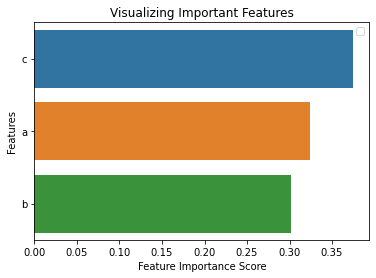

```python
sns.barplot(x=feature_imp, y=feature_imp.index)

plt.xlabel('Feature Importance Score')
plt.ylabel('Features')
plt.title("Visualizing Important Features")
plt.legend()
plt.show()
```

```python
print('*************** Evaluation on Data ***************')
score = clf.score(X, y)
predict = clf.predict(X)

# Look at classification report to evaluate the model
print(classification_report(y, predict))
print('--------------------------------------------------------')
print("")
print("Accuracy:",accuracy_score(y, y_pred))
```

```
*************** Evaluation on Data ***************
              precision    recall  f1-score   support

           1       0.94      0.99      0.96      1249
           2       0.99      0.93      0.96      1251

    accuracy                           0.96      2500
   macro avg       0.96      0.96      0.96      2500
weighted avg       0.97      0.96      0.96      2500

--------------------------------------------------------

Accuracy: 0.9632
```

### Question 3: AdaBoost Classifier

- AB implementation (15 pts)
- Classification using AdaBoostClassifier (5 pts)
- Evaluation (5 pts)

```python
# Firstly, we are going to set a based decision tree function as decision stump

def decisionTree(data,sample_weight):
    # the shape of dataset
    n=data.shape[1]

    for i in range(n):
        feature = data[:,i]

        feature_unique = np.sort(np.unique(feature)) # sort the feature

        for j in range(len(feature_unique)):
            # setting the threshold value
            threshold = (feature_unique[j] + feature_unique[j+1])/2

            # to distinguish what threshold as the true features
            for z in (0,1):
                if z==1:
                    y = 2*(feature>= threshold)-1
                else:
                    y =2*(feature < threshold)-1
                err = np.sum((y != y)*sample_weight)

    return err


#Secondly, to set a AdaBoostClassifier

estimators =[]
alphas = []
def my_adaboost(data,n_estimators=100):

    sample_weight = np.ones(len(data))/len(data) # initialize the sample as 1/N

    for i in range(n_estimators):
        # dc is from decisionTree()
        dc = decisionTree(data,sample_weight) #dc return an error

        alpha = 1/2 *np.log((1-dc)/dc) # the weight of the lastest estimator

        y_pred = dc.predict(data)# Sorry, I do not set the predict function
        #,but something like if the feature is true, then 2*(feature >= best_threshold)-1
        # else 2*(feature >= best_threshold)-1

        sample_weight *= np.exp(-alpha*y_pred*y)

        sample_weight /= np.sum(sample_weight) # sum all the estimators

        estimators.append(dc)
        alpha.append(alpha)

    return estimators,alpha
```

```python
Ada_model = AdaBoostClassifier(n_estimators=50,learning_rate=1)
Ada_model.fit(X,y)

y_pred = model.predict(X)
```

```python
print('*************** Evaluation on Data ***************')
score = Ada_model.score(X, y)
predict = Ada_model.predict(X)

# Look at classification report to evaluate the model
print(classification_report(y, predict))
print('--------------------------------------------------------')
print("")
print("Accuracy:",accuracy_score(y, y_pred))
```

```
*************** Evaluation on Data ***************
              precision    recall  f1-score   support

           1       1.00      1.00      1.00      1249
           2       1.00      1.00      1.00      1251

    accuracy                           1.00      2500
   macro avg       1.00      1.00      1.00      2500
weighted avg       1.00      1.00      1.00      2500

--------------------------------------------------------

Accuracy: 0.9996
```

### Question 4: Gradient Boost Classifier

- GB implementation (15 pts)
- Classification using GradientBoostingClassifier (5 pts)
- Evaluation (5 pts)

```python
# pretend we have regeressiontree, as for classification we need to count residual

def my_gradient_boost(data,n_estimators):

    regression_tree.fit(data.iloc[:,:3],data['class'])
    y_pred = regerssion.predict(data.iloc[:,:3],data['class'])

    for i in range(n_estimators):

        gradient = loss.gradient(y,y_pred)
        regerssion_tree[i].fit(data.iloc[:,:3],gradient) # for loop is for the next tree to fit the tree before it

        y_ pred -=np.multiply(learning_rate,regerssion_tree[i].predict(data.iloc[:,:3]) )

        # to cauclate the sum the residual and max probability of y_pred
        y_pred = np.exp(y_pred)/np.expand_dims(np.sum(np.exp(y_pred), axis=1), axis=1)
        y_pred = np.argmax(y_pred)
```

```python
GBC = GradientBoostingClassifier(n_estimators=100, learning_rate=0.5,max_depth=3, random_state=0)
GBC.fit(X, y)
```

```
GradientBoostingClassifier(learning_rate=0.5, random_state=0)
```

```python
print('*************** Evaluation on Data ***************')
score = GBC.score(X, y)
predict = GBC.predict(X)

# Look at classification report to evaluate the model
print(classification_report(y, predict))
print('--------------------------------------------------------')
print("")
print("Accuracy:",accuracy_score(y, y_pred))
```

```
*************** Evaluation on Data ***************
              precision    recall  f1-score   support

           1       1.00      1.00      1.00      1249
           2       1.00      1.00      1.00      1251

    accuracy                           1.00      2500
   macro avg       1.00      1.00      1.00      2500
weighted avg       1.00      1.00      1.00      2500

--------------------------------------------------------

Accuracy: 0.9996
```